# Ville T. Aro

The accuracy of our model is the following:

```r
ratio <- c(correct/total)
ratio
```

```
## [1] 0.6568627
```

Now we reload the Boston dataset and standardize it. Then we take a look at the distances between the variables.

```r
New_Boston <- Boston

str(New_Boston)
```

```
## 'data.frame':    506 obs. of  14 variables:
##  $ crim   : num  0.00632 0.02731 0.02729 0.03237 0.06905 ...
##  $ zn     : num  18 0 0 0 0 0 12.5 12.5 12.5 12.5 ...
##  $ indus  : num  2.31 7.07 7.07 2.18 2.18 2.18 7.87 7.87 7.87 7.87 ...
##  $ chas   : int  0 0 0 0 0 0 0 0 0 0 ...
##  $ nox    : num  0.538 0.469 0.469 0.458 0.458 0.458 0.524 0.524 0.524 0.524 ...
##  $ rm     : num  6.58 6.42 7.18 7 7.15 ...
##  $ age    : num  65.2 78.9 61.1 45.8 54.2 58.7 66.6 96.1 100 85.9 ...
##  $ dis    : num  4.09 4.97 4.97 6.06 6.06 ...
##  $ rad    : int  1 2 2 3 3 3 5 5 5 5 ...
##  $ tax    : num  296 242 242 222 222 222 311 311 311 311 ...
##  $ ptratio: num  15.3 17.8 17.8 18.7 18.7 18.7 15.2 15.2 15.2 15.2 ...
##  $ black  : num  397 397 393 395 397 ...
##  $ lstat  : num  4.98 9.14 4.03 2.94 5.33 ...
##  $ medv   : num  24 21.6 34.7 33.4 36.2 28.7 22.9 27.1 16.5 18.9 ...
```

```r
New_Boston_scaled <- scale(New_Boston) %>% as.data.frame()

str(New_Boston_scaled)
```

```
## 'data.frame':    506 obs. of  14 variables:
##  $ crim   : num  -0.419 -0.417 -0.417 -0.416 -0.412 ...
##  $ zn     : num  0.285 -0.487 -0.487 -0.487 -0.487 ...
##  $ indus  : num  -1.287 -0.593 -0.593 -1.306 -1.306 ...
##  $ chas   : num  -0.272 -0.272 -0.272 -0.272 -0.272 ...
##  $ nox    : num  -0.144 -0.74 -0.74 -0.834 -0.834 ...
##  $ rm     : num  0.413 0.194 1.281 1.015 1.227 ...
##  $ age    : num  -0.12 0.367 -0.266 -0.809 -0.511 ...
##  $ dis    : num  0.14 0.557 0.557 1.077 1.077 ...
##  $ rad    : num  -0.982 -0.867 -0.867 -0.752 -0.752 ...
##  $ tax    : num  -0.666 -0.986 -0.986 -1.105 -1.105 ...
##  $ ptratio: num  -1.458 -0.303 -0.303 0.113 0.113 ...
##  $ black  : num  0.441 0.441 0.396 0.416 0.441 ...
##  $ lstat  : num  -1.074 -0.492 -1.208 -1.36 -1.025 ...
##  $ medv   : num  0.16 -0.101 1.323 1.182 1.486 ...
```

Now we calculate the distances.

```r
# Euclidean distance matrix using set.seed()
set.seed(123)
dist_eu <- dist(New_Boston_scaled)
summary(dist_eu)
```

```
##    Min. 1st Qu.  Median    Mean 3rd Qu.    Max.
##  0.1343  3.4620  4.8240  4.9110  6.1860 14.4000
```

This is based on the Euclidean measure. And above you see the summary of the findings. Now we can start the clustering with the amount of 10 clusters. 10 is a safe bet that nothing would go wrong, below I calculate the optimum amount of clusters.

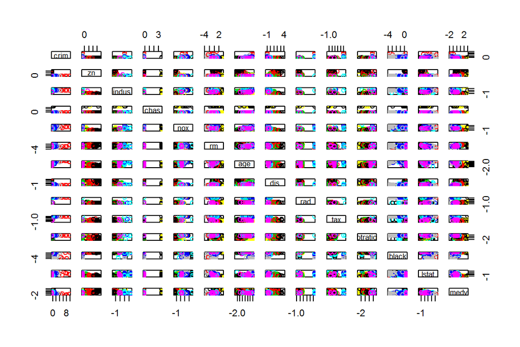

```r
library(ggplot2)

km <-kmeans(dist_eu, centers=10)
pairs(New_Boston_scaled, col = km$cluster)
```

As there is 10 clusters at the moment it is really hard to see what actually happens in this plot.

Because of this we want to optimize the amount of clusters so we don’t have to guess it and then we can take a look at the plot again..

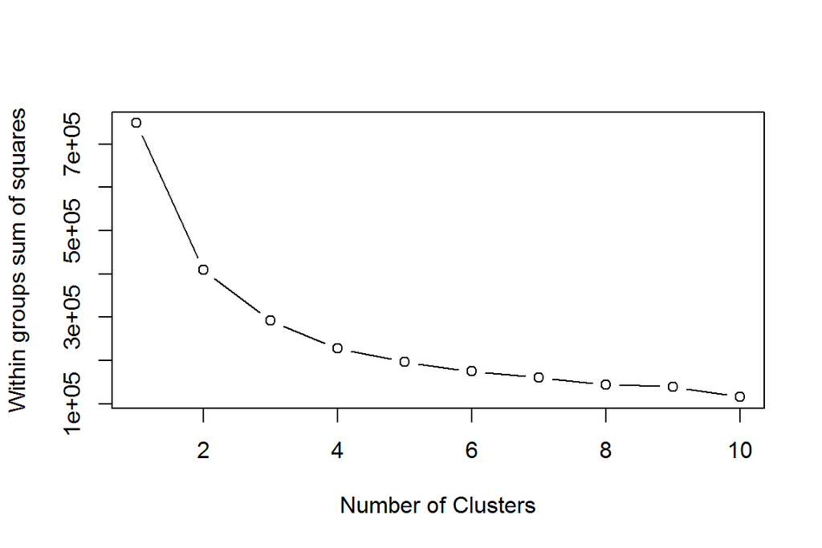

```r
k_max <- 10
wss <- sapply(1:k_max, function(k){kmeans(dist_eu, k)$tot.withinss})
plot(1:k_max, wss, type="b", xlab="Number of Clusters",
  ylab="Within groups sum of squares")
```

It seems that the optimal amount of clusters is 2. So we run the cluster analysis again and then take a look at the plot.

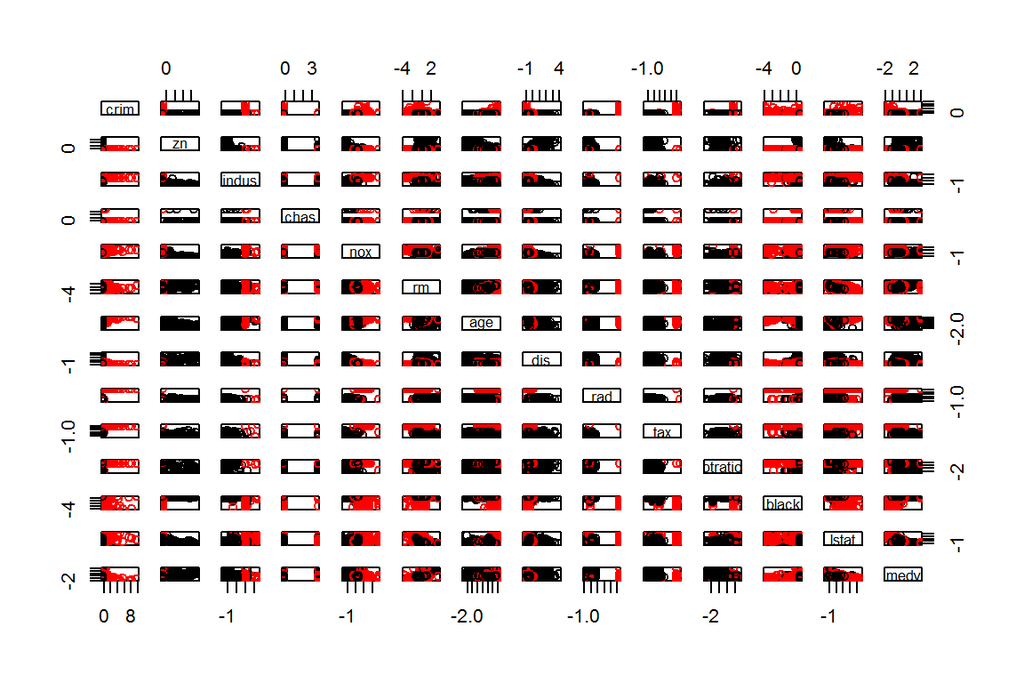

```r
km <-kmeans(dist_eu, centers=2)
pairs(New_Boston_scaled, col = km$cluster)
```

Next we perform LDA using the clusters as target classes. We include all the variables in the Boston data in the LDA model.

```r
km <-kmeans(dist_eu, centers = 3)
lda.fits <- lda(km$cluster~., data = myboston_scaled)
lda.fits
```

```
## Call:
## lda(km$cluster ~ ., data = myboston_scaled)
##
## Prior probabilities of groups:
##         1         2         3
## 0.1383399 0.2569170 0.6047431
##
## Group means:
##           zn      indus        chas        nox         rm        age
## 1 -0.4321124  1.0399621  0.62757956  1.2667725 -0.5975497  0.8264008
## 2 -0.4872402  1.0743771 -0.18147291  0.7905978 -0.3261484  0.7799367
## 3  0.3058467 -0.6943345 -0.06646762 -0.6256594  0.2752542 -0.5203916
##          dis        rad        tax    ptratio        black      lstat
## 1 -0.9294285  1.1838094  1.2037534  0.2897641 -1.547587007  1.0514755
## 2 -0.7234163  0.7284612  0.8572944  0.5527964  0.004362524  0.6244404
## 3  0.5199481 -0.5802831 -0.6395785 -0.3011341  0.352169811 -0.5058188
##         medv crime_categorymed_low crime_categorymed_high
## 1 -0.6373069            0.01428571              0.2000000
## 2 -0.5333324            0.10000000              0.3230769
## 3  0.3723683            0.36601307              0.2287582
##   crime_categoryhigh
## 1          0.7714286
## 2          0.5615385
## 3          0.0000000
##
## Coefficients of linear discriminants:
##                                LD1         LD2
## zn                     -0.39468364 -0.09677448
## indus                  -1.36978210 -1.03566594
## chas                   -0.29441343  0.53112017
## nox                    -0.54054935  0.56258301
## rm                      0.18662157 -0.41617536
## age                    -0.18175313 -0.30440972
## dis                    -0.08851529 -0.03497269
## rad                    -0.30229151 -0.04071641
## tax                    -0.35134096  0.17638898
## ptratio                -0.10630867 -0.07487010
## black                   0.47176537 -1.09887695
## lstat                  -0.40545791  0.29469437
## medv                   -0.31423331  0.48310594
## crime_categorymed_low   0.61873110 -0.06078345
## crime_categorymed_high  0.09629715 -0.73535354
## crime_categoryhigh     -0.08179388 -0.84651510
##
## Proportion of trace:
##    LD1    LD2
## 0.9151 0.0849
```

Now we visualize the results with a biplot and then analyze the results.

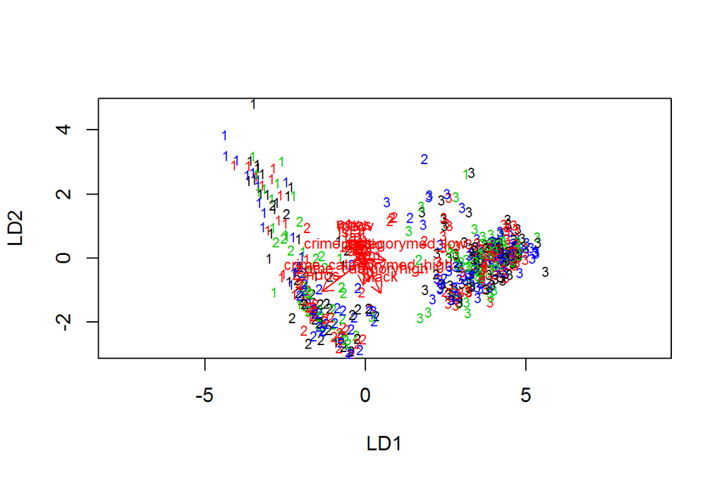

```r
plot(lda.fits, dimen = 2, col = classes)
lda.arrows(lda.fits, myscale = 1)
```

The last thing to do is 3d modeling. It really tops this weeks project as it gives us a really clear model that we can also move 360 degrees. It helps us analyse the findings and understand the model.

```r
model_predictors <- dplyr::select(train, -crime_category)


dim(model_predictors)
```

```
## [1] 404  13
```

```r
dim(lda.fit$scaling)
```

```
## [1] 13  3
```

```r
matrix_product <- as.matrix(model_predictors) %*% lda.fit$scaling
matrix_product <- as.data.frame(matrix_product)


plot_ly(x = matrix_product$LD1, y = matrix_product$LD2, z = matrix_product$LD3, type= 'scatter3d', mode='markers', color = classes,
        colors=c("blue","yellow") )
```

[interactive chart not shown]